# Statistics with Python - 2

# (Multivariate)

## Multivariate Data

### Multivariate Categorical Data

- Two-way or Contingency Tables
- Marginal and Conditional Distributions
- Graphs: Bar Charts, Side-by-side Bar Charts, Stacked Bar, Charts, and Mosaic Plots

```python
import pandas as pd
import numpy as np
import Toggle
pd.set_option('display.max_rows', 10)
df = pd.read_csv('dataSet.csv')
df = df.rename(columns={"SEQN":"Id","RIAGENDR":"Gender","RIDRETH1":"Race","DMDMARTL":"Marital_Status"})
gen_dict = {1: "Male", 2: "Female"}
race_dict = {1:"Mexican American",2:"Other Hispanic",3:"Non-Hispanic White",4:"Non-Hispanic Black",5:"Other Race"}
marital_dict = {1:"Married",2:"Widowed",3:"Divorced",4:"Separated",5:"Never married",
                6:"Living with partner",77:"Refused",99:"Don't Know",np.nan:"Missing"}
df = df.replace({"Gender": gen_dict,"Race":race_dict,"Marital_Status":marital_dict})
dfx = df[['Id','Gender','Race','Marital_Status']].copy(deep=True)
print(len(dfx))
print('Gender : ',set(dfx.Gender.values))
print('Race : ',set(dfx.Race.values))
print('Marital_Status : ',set(dfx.Marital_Status.values))
display(dfx)
Toggle.hide_toggle()
```

```
5735
Gender :  {'Female', 'Male'}
Race :  {'Mexican American', 'Other Race', 'Non-Hispanic Black', 'Other Hispanic', 'Non-Hispanic White'}
Marital_Status :  {'Refused', 'Widowed', 'Divorced', 'Never married', 'Living with partner', 'Married', 'Missing', 'Separated'}
```

|  | Id | Gender | Race | Marital_Status |
| --- | --- | --- | --- | --- |
| 0 | 83732 | Male | Non-Hispanic White | Married |
| 1 | 83733 | Male | Non-Hispanic White | Divorced |
| 2 | 83734 | Male | Non-Hispanic White | Married |
| 3 | 83735 | Female | Non-Hispanic White | Living with partner |
| 4 | 83736 | Female | Non-Hispanic Black | Divorced |
| ... | ... | ... | ... | ... |
| 5730 | 93695 | Female | Non-Hispanic White | Widowed |
| 5731 | 93696 | Male | Non-Hispanic White | Married |
| 5732 | 93697 | Female | Non-Hispanic White | Widowed |
| 5733 | 93700 | Male | Non-Hispanic White | Married |
| 5734 | 93702 | Female | Non-Hispanic White | Never married |

5735 rows × 4 columns

S/H

```
Gender  Race
Female  Mexican American      543
        Non-Hispanic Black    651
        Non-Hispanic White    910
        Other Hispanic        428
        Other Race            444
Male    Mexican American      475
        Non-Hispanic Black    576
        Non-Hispanic White    929
        Other Hispanic        322
        Other Race            457
dtype: int64


TWO WAY TABLE
```

| Race Gender | Mexican American | Non-Hispanic Black | Non-Hispanic White | Other Hispanic | Other Race |
| --- | --- | --- | --- | --- | --- |
| Female | 543 | 651 | 910 | 428 | 444 |
| Male | 475 | 576 | 929 | 322 | 457 |

```
MOSAIC PLOT
```

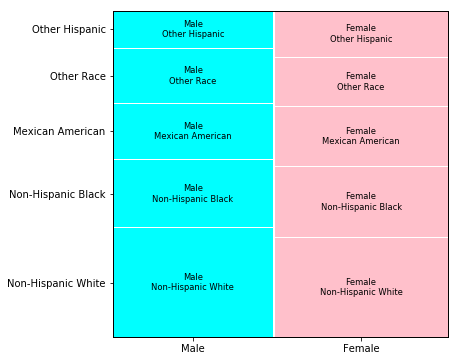

S/H

```python
import Toggle
from statsmodels.graphics.mosaicplot import mosaic
import matplotlib.pyplot as plt
grouped = dfx.groupby(['Gender','Race'])
print(grouped.size())
print('\n\nTWO WAY TABLE')
display(pd.crosstab(dfx.Gender,dfx.Race))
props = lambda key: {'facecolor': 'cyan' if 'Male' in key else 'pink'}
fig, axis = plt.subplots(1, 1,figsize=(6,6))
print('\n\nMOSAIC PLOT')
m = mosaic(dfx,['Gender','Race'],properties=props,ax=axis)
plt.show()
Toggle.hide_toggle()
```

### Multivariate Quantitative Data

- **Covariance** between two quantitative variables

Measures joint variability of two random variables  
$cov(X,Y) = \sigma_{XY} = \frac{\sum_{i=1}^{N}(x_i-\bar{x})(y_i-\bar{y})}{N}$  
$cov(X,Y) = \sigma_{XY} = \frac{\sum_{i=1}^{N}(x_i-\bar{x})(y_i-\bar{y})}{N-1}$ (unbiased estimate of population covariance)

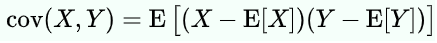

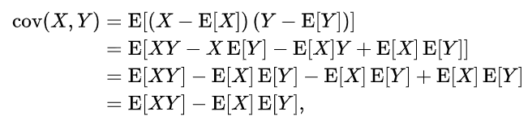

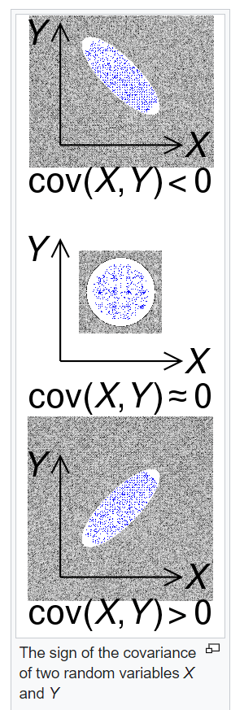

- **Correlation** between two quantitative variable

Correlation or dependence is any statistical relationship, whether causal or not, between two random variables or bivariate data. Generally used is **Pearson Correlation Coefficient**.

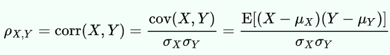

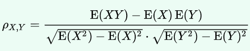

$\rho_{XY} = \frac{\sigma_{XY}}{{\sigma_X}{\sigma_Y}}$  
$\rho_{XX} = 1$

- **Covariance Matrix**

A covariance matrix (also known as auto-covariance matrix, dispersion matrix, variance matrix, or variance–covariance matrix) is a square matrix giving the covariance between each pair of elements of a given random vector. Any covariance matrix is symmetric and positive semi-definite and its main diagonal contains variances (i.e., the covariance of each element with itself).

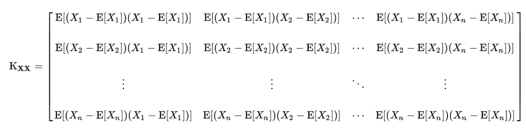

- **Correlation Matrix**

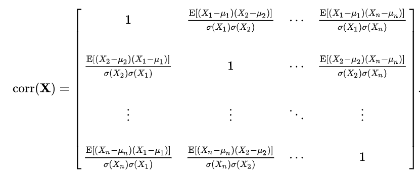

```
BMXBMI : Body Mass Index, BMXWAIST: Waist Circumference, BMXARMC: Arm Circumference, BMXARML: Arm Length
Sample Size :  5735
```

|  | BMXBMI | BMXWAIST | BMXARMC | BMXARML |
| --- | --- | --- | --- | --- |
| 0 | 27.8 | 101.1 | 35.9 | 43.6 |
| 1 | 30.8 | 107.9 | 33.2 | 40.0 |
| 2 | 28.8 | 116.5 | 31.0 | 37.0 |
| 3 | 42.4 | 110.1 | 38.3 | 37.7 |
| 4 | 20.3 | 80.4 | 27.2 | 36.0 |
| ... | ... | ... | ... | ... |
| 5730 | 21.5 | 95.0 | 29.5 | 37.0 |
| 5731 | 33.8 | 110.2 | 42.3 | 41.8 |
| 5732 | 31.0 | NaN | 28.8 | 37.5 |
| 5733 | 26.0 | 98.9 | 30.6 | 37.5 |
| 5734 | 21.4 | 72.5 | 26.2 | 33.5 |

5735 rows × 4 columns

```
 Covariance Matrix
```

|  | BMXBMI | BMXWAIST | BMXARMC | BMXARML |
| --- | --- | --- | --- | --- |
| BMXBMI | 50.352094 | 107.352080 | 32.415414 | 4.022559 |
| BMXWAIST | 107.352080 | 283.723993 | 71.834927 | 16.666412 |
| BMXARMC | 32.415414 | 71.834927 | 27.752113 | 6.494620 |
| BMXARML | 4.022559 | 16.666412 | 6.494620 | 7.844390 |

```
 Correlation Matrix
```

|  | BMXBMI | BMXWAIST | BMXARMC | BMXARML |
| --- | --- | --- | --- | --- |
| BMXBMI | 1.000000 | 0.910781 | 0.874817 | 0.204285 |
| BMXWAIST | 0.910781 | 1.000000 | 0.814188 | 0.354386 |
| BMXARMC | 0.874817 | 0.814188 | 1.000000 | 0.441430 |
| BMXARML | 0.204285 | 0.354386 | 0.441430 | 1.000000 |

```
 Correlation Heat Map
```

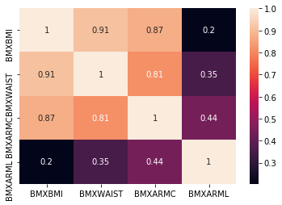

```
 Scatter Matrix
```

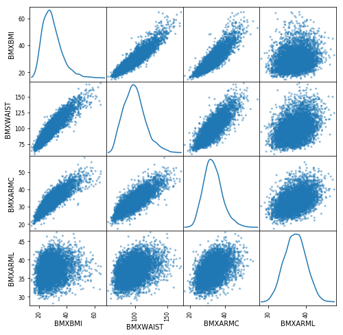

S/H

```python
from pandas.plotting import scatter_matrix
import seaborn as sns
pd.set_option('display.max_rows', 10)
print('BMXBMI : Body Mass Index, BMXWAIST: Waist Circumference, BMXARMC: Arm Circumference, BMXARML: Arm Length')
print('Sample Size : ',len(df))
dfa = df[['BMXBMI','BMXWAIST','BMXARMC','BMXARML']].copy(deep=True)
display(dfa)
print('\n\n Covariance Matrix')
display(dfa.cov())
print('\n\n Correlation Matrix')
display(dfa.corr())
# calculate the correlation matrix
corr = dfa.corr()
# plot the heatmap
print('\n\n Correlation Heat Map')
sns.heatmap(corr, xticklabels=corr.columns, yticklabels=corr.columns,annot=True)
plt.show()
print('\n\n Scatter Matrix')
axes = scatter_matrix(dfa, alpha=0.5, diagonal='kde',figsize=(8, 8))
plt.show()
Toggle.hide_toggle()
```

### Partial Correlation

*(Requires understanding of linear regression)*  
Partial correlation measures the degree of association between two random variables, with the effect of a set of controlling random variables removed.  
If we are interested in finding to what extent there is a numerical relationship between two variables of interest, using their correlation coefficient will give misleading results if there is another, confounding, variable that is numerically related to both variables of interest.  
This misleading information can be avoided by controlling for the confounding variable, which is done by computing the partial correlation coefficient.

```python
import Toggle
dfb = df[['BMXBMI','BMXWAIST','BMXARMC']].copy(deep=True)
print('BMXBMI : Body Mass Index (BMI), BMXWAIST: Waist Circumference (WC), BMXARMC: Arm Circumference(AC)')
print('\n\n Correlation Matrix')
display(dfb.corr())
Toggle.hide_toggle()
```

```
BMXBMI : Body Mass Index (BMI), BMXWAIST: Waist Circumference (WC), BMXARMC: Arm Circumference(AC)


 Correlation Matrix
```

|  | BMXBMI | BMXWAIST | BMXARMC |
| --- | --- | --- | --- |
| BMXBMI | 1.000000 | 0.910781 | 0.874817 |
| BMXWAIST | 0.910781 | 1.000000 | 0.814188 |
| BMXARMC | 0.874817 | 0.814188 | 1.000000 |

S/H

BMI is correlated with AC  
WC is correlated with AC  
BMI is correlated with WC  
Can we find the correlation between BMI and WC controlling the correlation due to AC ?  
Let's say BMI = Y, WC = X and AC = Z  
We do a linear regression X ~ Z and the calculate residual of X i.e. $e_X$  
Next we do a linear regression Y ~ Z and the calculate residual of Y i.e. $e_Y$  
Partial correlation between X & Y ($\rho_{XY.Z}$) is correlation between $e_X$ and $e_Y$ i.e. $\rho_{e_Xe_Y}$

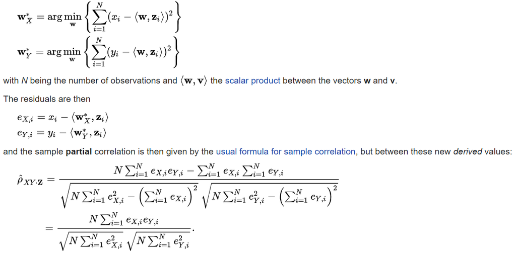

```python
#print(len(dfb))
dfc = dfb.dropna().copy(deep=True)
#print(len(dfc))
print('Dataframe after dropping NaN values:')
display(dfc)
Toggle.hide_toggle()
```

```
Dataframe after dropping NaN values:
```

|  | BMXBMI | BMXWAIST | BMXARMC |
| --- | --- | --- | --- |
| 0 | 27.8 | 101.1 | 35.9 |
| 1 | 30.8 | 107.9 | 33.2 |
| 2 | 28.8 | 116.5 | 31.0 |
| 3 | 42.4 | 110.1 | 38.3 |
| 4 | 20.3 | 80.4 | 27.2 |
| ... | ... | ... | ... |
| 5729 | 21.0 | 75.4 | 23.8 |
| 5730 | 21.5 | 95.0 | 29.5 |
| 5731 | 33.8 | 110.2 | 42.3 |
| 5733 | 26.0 | 98.9 | 30.6 |
| 5734 | 21.4 | 72.5 | 26.2 |

5353 rows × 3 columns

S/H

```python
from sklearn.linear_model import LinearRegression
Y = np.reshape(dfc.BMXBMI.values,(-1,1))
X = np.reshape(dfc.BMXWAIST.values,(-1,1))
Z = np.reshape(dfc.BMXARMC.values,(-1,1))
regYZ = LinearRegression().fit(Z,Y)
regXZ = LinearRegression().fit(Z,X)
Yp = regYZ.predict(Z)
Xp = regXZ.predict(Z)
Ey = Y - Yp
Ex = X - Xp
Ex = Ex.flatten()
Ey = Ey.flatten()
print('Correlation Matrix')
display(dfc.corr())
pcdf = pd.DataFrame(np.corrcoef(Ex,Ey),index=['BMXWAIST','BMXBMI'],columns=['BMXWAIST','BMXBMI'])
print('\n\nPartial Correlation Matrix')
display(pcdf)
print('Clearly, values have decreased')
Toggle.hide_toggle()
```

```
Correlation Matrix
```

|  | BMXBMI | BMXWAIST | BMXARMC |
| --- | --- | --- | --- |
| BMXBMI | 1.000000 | 0.910968 | 0.874748 |
| BMXWAIST | 0.910968 | 1.000000 | 0.814563 |
| BMXARMC | 0.874748 | 0.814563 | 1.000000 |

```
Partial Correlation Matrix
```

|  | BMXWAIST | BMXBMI |
| --- | --- | --- |
| BMXWAIST | 1.000000 | 0.705927 |
| BMXBMI | 0.705927 | 1.000000 |

```
Clearly, values have decreased
```

S/H